# PEC 1 - Datos ómicos

Merce Merayo Pastor

2024-10-26

```r
library(readr)
library(SummarizedExperiment)
library(tibble)
library(dplyr)
library(tidyr)
library(kableExtra)
library(mixOmics)
library(ggplot2)
```

# 1 Resumen ejecutivo

Este informe presenta un análisis del dataset de metabolómica correspondiente al estudio **ST003471** del repositorio **MetabolomicsWorkbench**, parte del proyecto **PR002130**. El estudio, titulado “*Gut Microbiota Regulates Stress Responsivity via the Circadian System - Mice Hippocampus*”, examina cómo la microbiota intestinal influye en la regulación de la respuesta al estrés a través del sistema circadiano, utilizando como modelo el hipocampo de ratones.

La investigación original revela que el estrés y los sistemas circadianos están interconectados a través del eje hipotálamo-hipofisario-adrenal (HPA), el cual regula respuestas a estímulos externos. En este contexto, se descubrió que la microbiota intestinal actúa como un regulador clave de la función rítmica del eje HPA. Los hallazgos sugieren que el agotamiento de la microbiota altera significativamente tanto el transcriptoma como el metaboloma cerebral en regiones como el hipocampo y la amígdala, especialmente en vías relacionadas con la respuesta al estrés. Este efecto incluye una disrupción en los ritmos de secreción de glucocorticoides, lo que afecta las respuestas adaptativas al estrés en diferentes momentos del día. [1]

En el análisis actual, se emplean herramientas de bioinformática en **R**, incluyendo **Bioconductor** y los paquetes **SummarizedExperiment** y **mixOmics**, para realizar un análisis de componentes principales (PCA) y clustering, para poder explorar la variabilidad entre muestras y la identificación de posibles patrones de agrupamiento. Los resultados obtenidos ofrecen una visión de las principales fuentes de variación en los datos, lo que permite entender mejor cómo la microbiota intestinal podría modular las respuestas al estrés de forma circadiana.

Este trabajo demuestra la utilidad de las técnicas de análisis multivariante en bioinformática y cómo estas pueden contribuir a la comprensión de la influencia de la microbiota en la regulación de la respuesta al estrés en estudios metabolómicos.

# 2 Objetivos del Estudio

El objetivo de este análisis es realizar una exploración de los datos de metabolómica del hipocampo de ratones para:

1. Identificar y cuantificar las principales fuentes de variación entre las muestras mediante análisis de componentes principales (PCA), evaluando cómo estas variaciones podrían relacionarse con la influencia de la microbiota en la regulación de la respuesta al estrés de forma circadiana.
2. Comprobar si existe algún agrupamiento de interés entre muestras mediante técnicas de clustering, lo que permitiría detectar patrones en los metabolitos que puedan asociarse con las diferencias en los ritmos circadianos y la respuesta al estrés.
3. Utilizar herramientas bioinformáticas para proporcionar un análisis reproducible de los datos metabolómicos, con la finalidad de comprender la regulación circadiana de la respuesta al estrés relacionada con la microbiota.

Este estudio busca demostrar cómo los métodos multivariantes pueden mostrar patrones en los datos de metabolómica que reflejan interacciones biológicas complejas.

# 3 Materiales y Métodos

## 3.1 Origen y naturaleza de los datos

El dataset utilizado en este análisis proviene del estudio **ST003471** en el repositorio **MetabolomicsWorkbench**, que es parte del proyecto **PR002130** titulado “*Gut Microbiota Regulates Stress Responsivity via the Circadian System - Mice Hippocampus*”. Este estudio se centra en la relación entre la microbiota intestinal y la regulación de la respuesta al estrés en ratones, a través del sistema circadiano.

El conjunto de datos incluye medidas de abundancia relativa de diversos metabolitos en el hipocampo de ratones, una región del cerebro implicada en el procesamiento de la respuesta al estrés. Las muestras fueron recolectadas a lo largo de diferentes momentos del día para observar cómo la microbiota podría modular las respuestas al estrés de manera circadiana. Estos datos permiten una exploración de las vías metabólicas y cómo varían en función de la presencia o ausencia de microbiota, ofreciendo una ventana para entender la ritmicidad y la influencia de factores externos en los sistemas de respuesta al estrés. [1]

## 3.2 Herramientas bioinformáticas utilizadas

Se utilizaron varias herramientas en el entorno de programación **R**, incluyendo:

- **Bioconductor**: plataforma que proporciona acceso a paquetes bioinformáticos específicos para el análisis de datos ómicos.
- **SummarizedExperiment**: paquete empleado para organizar los datos metabolómicos y sus metadatos en un solo contenedor, permitiendo una manipulación estructurada y coherente.
- **mixOmics**: utilizado para llevar a cabo análisis de componentes principales (PCA) y clustering, métodos multivariantes clave para explorar patrones de agrupamiento en los datos.

Estas herramientas han sido necesarias para estructurar y analizar los datos de forma reproducible, además de explorar la variabilidad de las muestras y visualizar patrones relacionados con la respuesta al estrés y el sistema circadiano.

# 4 Resultados

## 4.1 Carga de los datos y metadatos desde `www.metabolomicsworkbench.org`

```r
url_matrix <- "https://www.metabolomicsworkbench.org/data/showfile_t.php?RA=185.110.33.198&DF=MSdata_ST003471_1.txt"

# Cargar datos del experimento
data_ST003471 <- read.delim(url_matrix, sep = "\t", header = TRUE, skip = 1)

head(data_ST003471[,1:5])
```

|  | Metabolite_name | RefMet_name | ABX_62 | ABX_63 | ABX_64 |
| --- | --- | --- | --- | --- | --- |
| 1 | Factors | - | Sample source:Hippocampus \| Treatment:ABX \| Zeitgeber_time:ZT11 | Sample source:Hippocampus \| Treatment:ABX \| Zeitgeber_time:ZT11 | Sample source:Hippocampus \| Treatment:ABX \| Zeitgeber_time:ZT11 |
| 2 | 1-Methyl Adenosine | 1-Methyladenosine | 3012420 | 2968448 | 2903435 |
| 3 | 2-Oxoglutaric acid | 2-Oxoglutaric acid | 31630 | 55513 | 9389 |
| 4 | 3-Methylhistidine | 3-Methylhistidine | 1053020 | 932342 | 1083327 |
| 5 | 4-Guanidinobutyric acid | 4-Guanidinobutanoic acid | 3646723 | 3425795 | 3132739 |
| 6 | 4-Hydroxybenzaldehyde | 4-Hydroxybenzaldehyde | 2546677 | 3157585 | 2563304 |

```r
url_metadata <- "https://www.metabolomicsworkbench.org/data/study_textformat_view.php?STUDY_ID=ST003471&ANALYSIS_ID=AN005706&MODE=d"

metadata_ST003471 <- read_tsv(url_metadata, comment = "#", skip = 4)
```

En los datos recuperados hay información sobre los metabolidos considerados en el estudio además de un segundo fichero con todos los metadatos de información sobre el proyecto. Por otro lado, hay identificadores de las muestras que incluyen información sobre el tratamiento en el propio identificador. Adicionalmente, hay información sobre el origen anatómico de la muestras, en este caso del hipocampo, tipo de tratamiento y el y el tiempo *Zeitgeber* (`Zeitgeber_time`). Este último, en estudios circadianos, hace referencia al tiempo en función de un sincronizador ambiental, normalmente el ciclo luz/oscuridad, donde “ZT” se refiere a la hora en relación con el comienzo del periodo de luz (ZT11) [2].

## 4.2 Preparación de los datos para el análisis

Para el análisis, primero es necesario realizar algunos pasos de limpieza y transformación de los datos. En particular, vamos a eliminar columnas innecesarias y extraer los detalles de las muestras de forma estructurada.

```r
# Eliminar RefMet_name
data_ST003471$RefMet_name <- NULL

# Capturar los detalles de las muestras
detalle_muestras <- t(data_ST003471[1, ])
```

Se extraen los detalles de las muestras, como el origen y tipo de tratamiento, para poder utilizar esta información más adelante.

**Creación de la matriz de metabolitos**: En este paso, se transforman los datos de los metabolitos en una matriz en la que las filas representan cada metabolito y las columnas representan cada muestra y se convierten los valores a formato numérico para facilitar el análisis.

```r
# Eliminar la primera fila y las dos últimas filas
matriz_metabolitos <- data_ST003471[-c(1, (nrow(data_ST003471) - 1), nrow(data_ST003471)), ]

# Capturar los identificadores de las muestras
nombre_muestras <- colnames(matriz_metabolitos)
nombre_muestras <- nombre_muestras[-1] # Eliminar el nombre de la columna de metabolitos

# Capturar los nombres de los metabolitos
(nombres_metabolitos <- matriz_metabolitos$Metabolite_name)
```

```
##   [1] "1-Methyl Adenosine"              "2-Oxoglutaric acid"
##   [3] "3-Methylhistidine"               "4-Guanidinobutyric acid"
##   [5] "4-Hydroxybenzaldehyde"           "7-Methylguanine"
##   [7] "Acetylcarnitine"                 "Acetylcholine"
##   [9] "Acetylhistidine"                 "Adenine"
##  [11] "Adenosine"                       "Alanine"
##  [13] "Aldopentose"                     "AMP"
##  [15] "Anserine"                        "Arginine"
##  [17] "Asparagine"                      "Aspartic acid"
##  [19] "Benzaldehyde"                    "Betaine"
##  [21] "Butyrylcarnitine"                "Carnitine"
##  [23] "Carnosine"                       "CDP-choline"
##  [25] "CDP-ethanolamine"                "Choline"
##  [27] "cis-Aconitic acid"               "Citrulline"
##  [29] "CMP"                             "Creatine"
```

[output cut: 41 more lines]

```r
matriz_metabolitos_valores <- matriz_metabolitos
matriz_metabolitos_valores$Metabolite_name <- NULL

# Guardar los datos relacionados con las muestras
tipo_muestras <- as.vector(detalle_muestras[-1])

# Obtener valor Zeitgeber_time
zeitgeber_time <- sub(".*Zeitgeber_time:(ZT[0-9]+).*", "\\1", tipo_muestras)

# Combinar nombre_muestras con zeitgeber_time
(identificador_muestras <- paste(nombre_muestras, zeitgeber_time, sep = "_"))
```

```
##  [1] "ABX_62_ZT11"  "ABX_63_ZT11"  "ABX_64_ZT11"  "ABX_65_ZT11"  "ABX_87_ZT11"
##  [6] "ABX_88_ZT11"  "ABX_89_ZT11"  "ABX_90_ZT11"  "ABX_104_ZT17" "ABX_105_ZT17"
## [11] "ABX_106_ZT17" "ABX_107_ZT17" "ABX_108_ZT17" "ABX_119_ZT17" "ABX_121_ZT17"
## [16] "ABX_109_ZT23" "ABX_110_ZT23" "ABX_111_ZT23" "ABX_112_ZT23" "ABX_113_ZT23"
## [21] "ABX_114_ZT23" "ABX_115_ZT23" "ABX_116_ZT23" "ABX_72_ZT5"   "ABX_73_ZT5"
## [26] "ABX_74_ZT5"   "ABX_75_ZT5"   "ABX_76_ZT5"   "ABX_77_ZT5"   "ABX_84_ZT5"
## [31] "ABX_86_ZT5"   "CV_101_ZT11"  "CV_102_ZT11"  "CV_16_ZT11"   "CV_17_ZT11"
## [36] "CV_18_ZT11"   "CV_19_ZT11"   "CV_20_ZT11"   "CV_122_ZT17"  "CV_123_ZT17"
## [41] "CV_66_ZT17"   "CV_67_ZT17"   "CV_68_ZT17"   "CV_69_ZT17"   "CV_70_ZT17"
## [46] "CV_71_ZT17"   "CV_117_ZT23"  "CV_118_ZT23"  "CV_78_ZT23"   "CV_79_ZT23"
## [51] "CV_80_ZT23"   "CV_81_ZT23"   "CV_82_ZT23"   "CV_83_ZT23"   "CV_10_ZT5"
## [56] "CV_11_ZT5"    "CV_12_ZT5"    "CV_13_ZT5"    "CV_6_ZT5"     "CV_7_ZT5"
## [61] "CV_8_ZT5"     "CV_9_ZT5"     "GF_32_ZT11"   "GF_36_ZT11"   "GF_41_ZT11"
## [66] "GF_42_ZT11"   "GF_43_ZT11"   "GF_45_ZT11"   "GF_47_ZT11"   "GF_48_ZT11"
## [71] "GF_91_ZT17"   "GF_92_ZT17"   "GF_93_ZT17"   "GF_94_ZT17"   "GF_95_ZT17"
## [76] "GF_96_ZT17"   "GF_97_ZT17"   "GF_98_ZT17"   "GF_53_ZT23"   "GF_54_ZT23"
## [81] "GF_55_ZT23"   "GF_56_ZT23"   "GF_57_ZT23"   "GF_59_ZT23"   "GF_60_ZT23"
## [86] "GF_61_ZT23"   "GF_24_ZT5"    "GF_25_ZT5"    "GF_26_ZT5"    "GF_27_ZT5"
## [91] "GF_28_ZT5"    "GF_49_ZT5"    "GF_51_ZT5"    "GF_52_ZT5"
```

```r
matriz_metabolitos_numerico <- matriz_metabolitos_valores %>% mutate(across(everything(), as.numeric))
matriz_metabolitos_numerico <- as.matrix(matriz_metabolitos_numerico)
```

### 4.2.1 Pasos durante la preparación de los datos

**Creación de la matriz de expresión de metabolitos y datos de las muestras**: Se genera una matriz que organiza los valores de expresión de los metabolitos para cada muestra, junto con un `data.frame` que contiene información de cada muestra, como su tratamiento y otros metadatos.

```r
# Crear la matriz con solo los valores de los metabolitos según la muestra
matriz_expresion_metabolitos <- matrix(
  data = matriz_metabolitos_numerico,
  nrow = 112,
  ncol = 94,
  dimnames = list(nombres_metabolitos, identificador_muestras)
)

# Información de las muestras
info_muestras <- data.frame(
  ID_muestra = identificador_muestras,
  info_muestra = tipo_muestras
)
```

**Limpieza y organización de la información de las muestras**: La información de cada muestra se organiza en un formato compatible con `Bioconductor`. Esto incluye separar datos clave (origen, tratamiento y tiempo circadiano) y limpiar etiquetas innecesarias para facilitar el análisis.

```r
# Convertir la información de las muestras en un DataFrame de Bioconductor
datos_columnas <- as(info_muestras, "DataFrame")
rownames(datos_columnas) <- datos_columnas$ID_muestra

# Crear un DataFrame para rowData de SE con la información de los metabolitos
datos_filas <- DataFrame(Metabolite_name = rownames(matriz_expresion_metabolitos))
rownames(datos_filas) <- datos_filas$Metabolite_name

# Separar los valores del vector `tipo_muestras`
info_muestras <- do.call(rbind, strsplit(tipo_muestras, " \\| "))
info_muestras <- as.data.frame(info_muestras)
colnames(info_muestras) <- c("Sample_source", "Treatment", "Zeitgeber_time")

# Limpiar los valores quitando el texto antes de los ":"
info_muestras$Sample_source <- sub("Sample source:", "", info_muestras$Sample_source)
info_muestras$Treatment <- sub("Treatment:", "", info_muestras$Treatment)
info_muestras$Zeitgeber_time <- sub("Zeitgeber_time:", "", info_muestras$Zeitgeber_time)
```

### 4.2.2 Creación del objeto `SummarizedExperiment`

Se construye un objeto `SummarizedExperiment` que integra los datos de expresión, información del proyecto, información de las muestras y detalles de los metabolitos.

```r
# Información del proyecto
info_proyecto <- list(
  Project_Title = colnames(metadata_ST003471)[2],
  Project_Summary = paste(metadata_ST003471[[2]][1:6], collapse = " "),
  Institute = metadata_ST003471[[2]][7],
  Department = metadata_ST003471[[2]][8],
  PI_Name = paste(metadata_ST003471[[2]][10:11], collapse = " "),
  Study_Title = paste(metadata_ST003471[[2]][16:17], collapse = " "),
  Study_Summary = paste(metadata_ST003471[[2]][18:33], collapse = " ")
)

# Crear el objeto SummarizedExperiment
se <- SummarizedExperiment(
  assays = SimpleList(counts = matriz_expresion_metabolitos),
  colData = datos_columnas,
  rowData = datos_filas,
  metadata = list(info_muestras = info_muestras, info_proyecto = info_proyecto)
)

# Inspeccionar objeto SummarizedExperiment
se
```

```
## class: SummarizedExperiment
## dim: 112 94
## metadata(2): info_muestras info_proyecto
## assays(1): counts
## rownames(112): 1-Methyl Adenosine 2-Oxoglutaric acid ... Valproic acid
##   Xanthine
## rowData names(1): Metabolite_name
## colnames(94): ABX_62_ZT11 ABX_63_ZT11 ... GF_51_ZT5 GF_52_ZT5
## colData names(2): ID_muestra info_muestra
```

Se accede a los metadatos sobre la información del proyecto:

```r
metadata(se)$info_proyecto
```

```
## $Project_Title
## [1] "Gut Microbiota Regulates Stress Responsivity via the Circadian System"
##
## $Project_Summary
## [1] "Metabolomics of adult mice Amygdala and Hippocampus. Samples collected from conventional, antibiotic-treated and germ-free mice across 4 timepoints of the day. The goal of the project is to investigate the role of the gut microbiota on the circadian patterns of metabolites in the brain. Resu…
##
## $Institute
## [1] "University College Cork"
##
## $Department
## [1] "Anatomy & Neuroscience"
##
## $PI_Name
## [1] "John Cryan"
##
## $Study_Title
## [1] "Gut Microbiota Regulates Stress Responsivity via the Circadian System - Mice Hippocampus"
##
## $Study_Summary
## [1] "Stress and circadian systems are interconnected through the hypothalamic-pituitary-adrenal (HPA) axis to maintain appropriate responses to external stimuli. Yet, the mechanisms of how such signals are orchestrated remains unknown. We now uncover the gut microbiota as a regulator of HPA-axis …
```

```r
# Guardar SummarizedExperiment en un .Rda
save(se, file = "SummarizedExperiment_ST003471_metadatos.Rda")
```

## 4.3 Análisis multivariante, PCA y clustering

El experimento consta de las medidas de 112 valores de diferentes metabolitos en 94 muestras. Para hacer un análisis multivariante, los metabolitos se consideran las variables y las muestras las observaciones, lo que permitirá hacer un análisis de correlación y clustering

Hasta este punto no se han detectado valores faltantes.

### 4.3.1 Estructura de datos con los metabolitos

Preparación del dataframe con los datos estructurados con los metabolitos como variables y las muestras como observaciones.

```r
# Transponer la matriz de concentraciones de metabolitos
metabolitos_df <- as.data.frame(t(matriz_expresion_metabolitos))
head(metabolitos_df[,1:5])
```

|  | 1-Methyl Adenosine | 2-Oxoglutaric acid | 3-Methylhistidine | 4-Guanidinobutyric acid | 4-Hydroxybenzaldehyde |
| --- | --- | --- | --- | --- | --- |
| ABX_62_ZT11 | 3012420 | 31630 | 1053020 | 3646723 | 2546677 |
| ABX_63_ZT11 | 2968448 | 55513 | 932342 | 3425795 | 3157585 |
| ABX_64_ZT11 | 2903435 | 9389 | 1083327 | 3132739 | 2563304 |
| ABX_65_ZT11 | 3068587 | 46558 | 961178 | 3396112 | 3231698 |
| ABX_87_ZT11 | 3260243 | 85443 | 1033778 | 5249595 | 2827167 |
| ABX_88_ZT11 | 2518544 | 139590 | 1103769 | 3970427 | 3801155 |

### 4.3.2 Análisis de colinearidad

En este paso se calcula la matriz de correlación de los metabolitos para detectar posibles casos de colinearidad, lo cual sería relevante si en futuros estudios se quisiera realizar algún análisis de regresión.

```r
# Calcular la matriz de correlación
matriz_corr_metab <- cor(metabolitos_df, use = "pairwise.complete.obs", method = "pearson")

# Convertir la matriz de correlación a un data frame para manipular los resultados
matriz_corr_metab_df <- as.data.frame(as.table(matriz_corr_metab))

# Filtrar aquellas correlaciones que sean mayores a 0.95 o menores a -0.95, excluyendo la diagonal
correlaciones_altas <- matriz_corr_metab_df %>%
  filter(abs(Freq) > 0.95 & abs(Freq) < 1)

# Renombrar las columnas para claridad
colnames(correlaciones_altas) <- c("Metabolito 1", "Metabolito 2", "Índice correlación")
```

Tabla de correlaciones altas (>0.95) entre metabolitos que se podrían considerar colinearidad:

```r
# Agregar numeración a las filas
correlaciones_altas$Casos <- seq_len(nrow(correlaciones_altas))

# Reorganizar para que la columna 'Fila' sea la primera
correlaciones_altas_num <- correlaciones_altas[, c("Casos", "Metabolito 1", "Metabolito 2", "Índice correlación")]

# Tabla kable
correlaciones_altas_num %>%
  kable(
    caption = "Correlaciones superiores a 0.95 entre metabolitos",
    digits = 3,
    align = "c"
  ) %>%
  kable_styling(
    bootstrap_options = c("striped", "hover", "condensed", "responsive"),
    full_width = FALSE
  ) %>%
  column_spec(4, bold = TRUE, color = "red")
```

Correlaciones superiores a 0.95 entre metabolitos

| Casos | Metabolito 1 | Metabolito 2 | Índice correlación |
| --- | --- | --- | --- |
| 1 | GMP | AMP | 0.957 |
| 2 | UMP | AMP | 0.960 |
| 3 | Ornithine | Arginine | 0.975 |
| 4 | AMP | GMP | 0.957 |
| 5 | IMP | GMP | 0.969 |
| 6 | UMP | GMP | 0.990 |
| 7 | Guanosine | Guanine | 0.996 |
| 8 | Guanine | Guanosine | 0.996 |
| 9 | Xanthine | Hypoxanthine | 0.970 |
| 10 | GMP | IMP | 0.969 |
| 11 | UMP | IMP | 0.970 |
| 12 | Leucine | Isoleucine | 0.975 |
| 13 | Phenylalanine | Isoleucine | 0.958 |
| 14 | Proline | Isoleucine | 0.952 |
| 15 | Valine/5-Amino valeric acid | Isoleucine | 0.969 |
| 16 | Isoleucine | Leucine | 0.975 |
| 17 | Methionine | Leucine | 0.958 |
| 18 | Phenylalanine | Leucine | 0.976 |
| 19 | Proline | Leucine | 0.957 |
| 20 | Valine/5-Amino valeric acid | Leucine | 0.952 |
| 21 | Proline | Lysine | 0.950 |
| 22 | Leucine | Methionine | 0.958 |
| 23 | Arginine | Ornithine | 0.975 |
| 24 | Isoleucine | Phenylalanine | 0.958 |
| 25 | Leucine | Phenylalanine | 0.976 |
| 26 | Proline | Phenylalanine | 0.958 |
| 27 | Isoleucine | Proline | 0.952 |
| 28 | Leucine | Proline | 0.957 |
| 29 | Lysine | Proline | 0.950 |
| 30 | Phenylalanine | Proline | 0.958 |
| 31 | AMP | UMP | 0.960 |
| 32 | GMP | UMP | 0.990 |
| 33 | IMP | UMP | 0.970 |
| 34 | Isoleucine | Valine/5-Amino valeric acid | 0.969 |
| 35 | Leucine | Valine/5-Amino valeric acid | 0.952 |
| 36 | Hypoxanthine | Xanthine | 0.970 |

Esta tabla ayuda a identificar si existen metabolitos con relaciones muy fuertes, lo cual es útil para evaluar si se pueden reducir las variables o tener en cuenta la colinearidad en futuros análisis.

### 4.3.3 Análisis de Clustering

Hay dos enfoques para realizar un análisis de clustering:

- Clustering de **muestras**: Para identificar si las muestras se agrupan en función de perfiles metabólicos similares.
- Clustering de **metabolitos**: Para identificar grupos de metabolitos que muestran patrones similares a lo largo de las muestras.

#### 4.3.3.1 Clustering de muestras

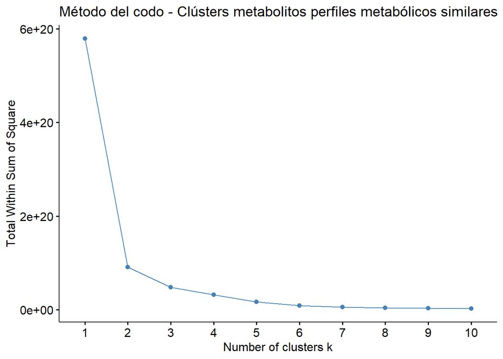

```r
library(cluster)
library(factoextra)

fviz_nbclust(matriz_expresion_metabolitos, FUN = hcut, method = "wss", k.max = 10) +
  ggtitle("Método del codo - Clústers metabolitos perfiles metabólicos similares")
```

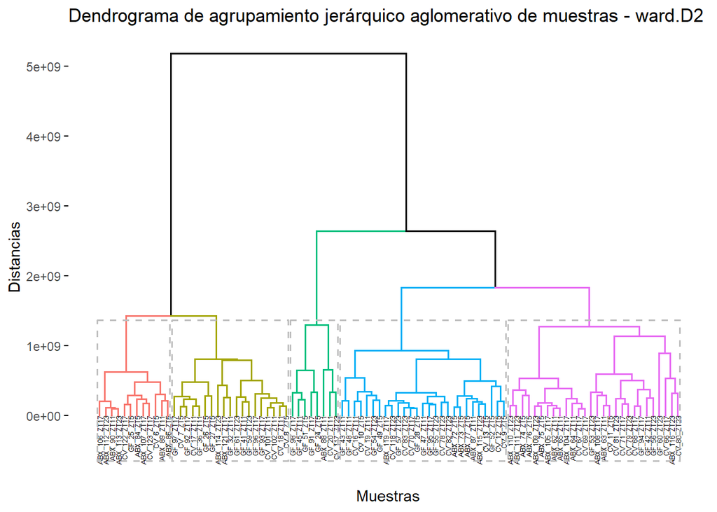

```r
# Clustering jerárquico con muestras
muestras_dist_matriz <- dist(metabolitos_df)
hclust_muestras <- hclust(muestras_dist_matriz, method = "ward.D2")

fviz_dend(hclust_muestras, cex = 0.35, k = 5, color_labels_by_k = FALSE, rect = TRUE,
          main = "Dendrograma de agrupamiento jerárquico aglomerativo de muestras - ward.D2", xlab = "Muestras", ylab = "Distancias")
```

En el dendograma no se observa una separación evidente únicamente por tratamiento o Zeitgeber_time, donde las letras del identificador de la muestra ABX, GF y CV indican el tipo de tratamiento.

#### 4.3.3.2 Clustering de metabolitos

Para identificar la agrupación óptima de metabolitos que presentan patrones similares a lo largo de las muestras y establecer el número de clústers se usa también el método del codo.

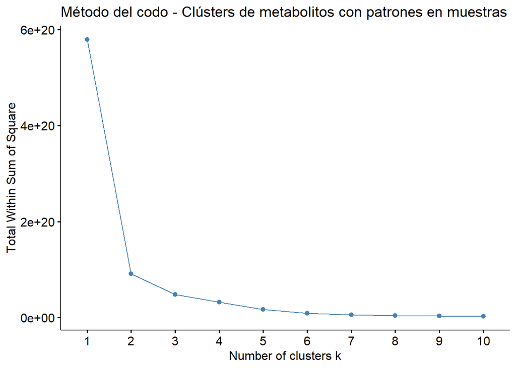

```r
fviz_nbclust(matriz_expresion_metabolitos, FUN = hcut, method = "wss", k.max = 10) +
  ggtitle("Método del codo - Clústers de metabolitos con patrones en muestras")
```

En este caso parece que con 3 clústers es suficiente para capturar la mayor parte de la estructura de variación en los datos.

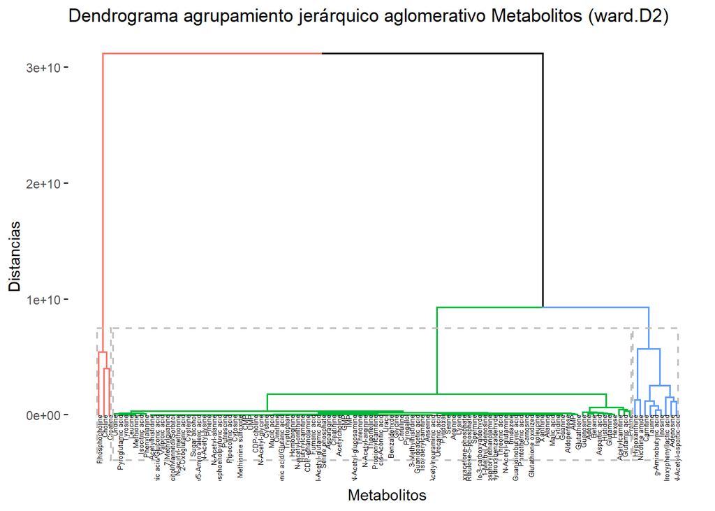

```r
# Clustering jerárquico con metabolitos
metabolitos_dist_matriz <- dist(matriz_expresion_metabolitos)
hclust_metabolitos <- hclust(metabolitos_dist_matriz, method = "ward.D2")

par(mar = c(10, 4, 4, 2) + 0.1)
fviz_dend(hclust_metabolitos, cex = 0.35, k = 3, color_labels_by_k = FALSE, rect = TRUE,
          main = "Dendrograma agrupamiento jerárquico aglomerativo Metabolitos (ward.D2)",
          xlab = "Metabolitos", ylab = "Distancias")
```

```r
# Crear los clústers para los metabolitos a partir del dendrograma
grupos_metabolitos <- cutree(hclust_metabolitos, k = 3)

table(grupos_metabolitos)
```

```
## grupos_metabolitos
##   1   2   3
## 100   9   3
```

```r
# Extraer metabolitos de cada grupo
metabolitos_verde <- names(grupos_metabolitos[grupos_metabolitos == 1])
metabolitos_azul <- names(grupos_metabolitos[grupos_metabolitos == 2])
metabolitos_rojo <- names(grupos_metabolitos[grupos_metabolitos == 3])

# Metabolitos en cada grupo - más interés por cluster con menos metabolítos
print("Metabolitos en el grupo rojo:")
```

```
## [1] "Metabolitos en el grupo rojo:"
```

```r
print(metabolitos_rojo)
```

```
## [1] "Choline"        "Creatine"       "Phosphocholine"
```

```r
#print("Metabolitos en el grupo verde:")
#print(metabolitos_verde)

print("Metabolitos en el grupo azul:")
```

```
## [1] "Metabolitos en el grupo azul:"
```

```r
print(metabolitos_azul)
```

```
## [1] "Adenosine"                "Carnitine"
## [3] "g-Aminobutyric acid"      "Hydroxyphenyllactic acid"
## [5] "Hypoxanthine"             "Inosine"
## [7] "N-Acetyl-aspartic acid"   "Nicotine amide"
## [9] "Taurine"
```

El clúster representado en rojo contiene 3 metabolitos (Choline, Creatine, Phosphocholine) que tienen un patrón de variación muy diferente en comparación con el resto de los metabolitos. Esto podría ser porque tienen funciones muy específicas y diferenciadas al resto de metabolitos.

Se analiza más en detalles si los metabolitos Choline, Creatine y Phosphocholine tienen distribuciones similares en términos de concentración.

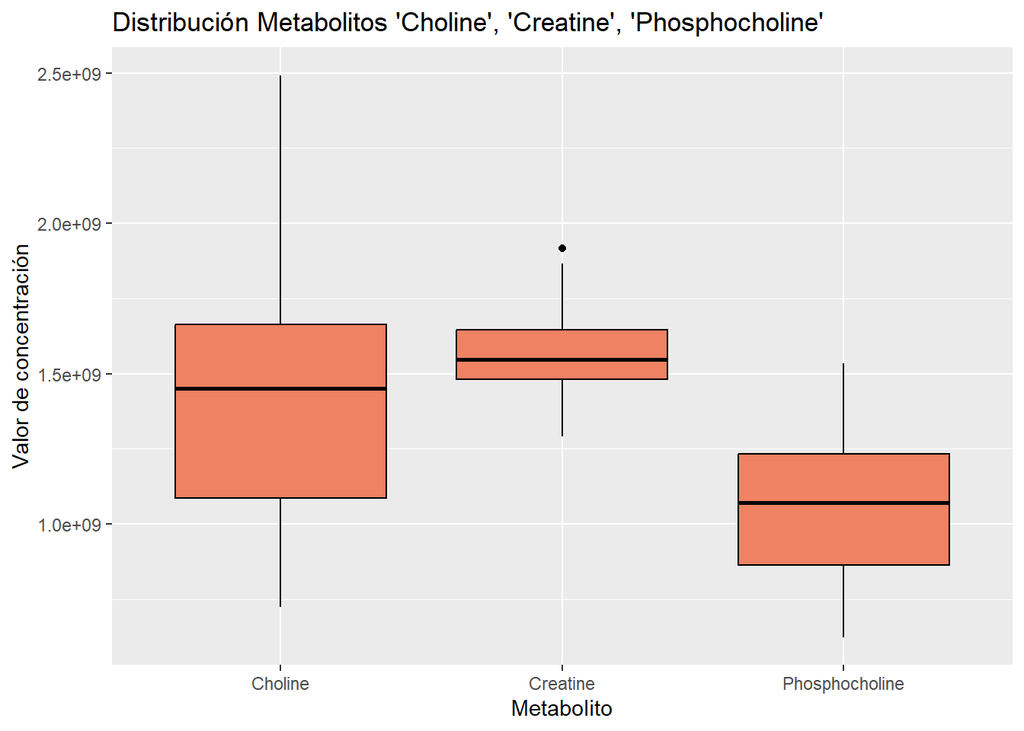

```r
# Primera columna = Muestra
colnames(metabolitos_df)[1] <- "Muestra"

df_metab_largo <- pivot_longer(metabolitos_df, cols = -Muestra, names_to = "Metabolito", values_to = "Valor")

# Filtrar metabolitos cluster rojo
metabolitos_rojo <- c("Choline", "Creatine", "Phosphocholine")
df_clusterrojo <- subset(df_metab_largo, Metabolito %in% metabolitos_rojo)

ggplot(df_clusterrojo, aes(x = Metabolito, y = Valor)) +
  geom_boxplot(fill = "salmon2", color = "black") +
  labs(title = "Distribución Metabolitos 'Choline', 'Creatine', 'Phosphocholine'",
    x = "Metabolito",
    y = "Valor de concentración")
```

Algo similar podría ocurrir en el clúster representado en azul, donde se han agrupado 9 metabolitos.

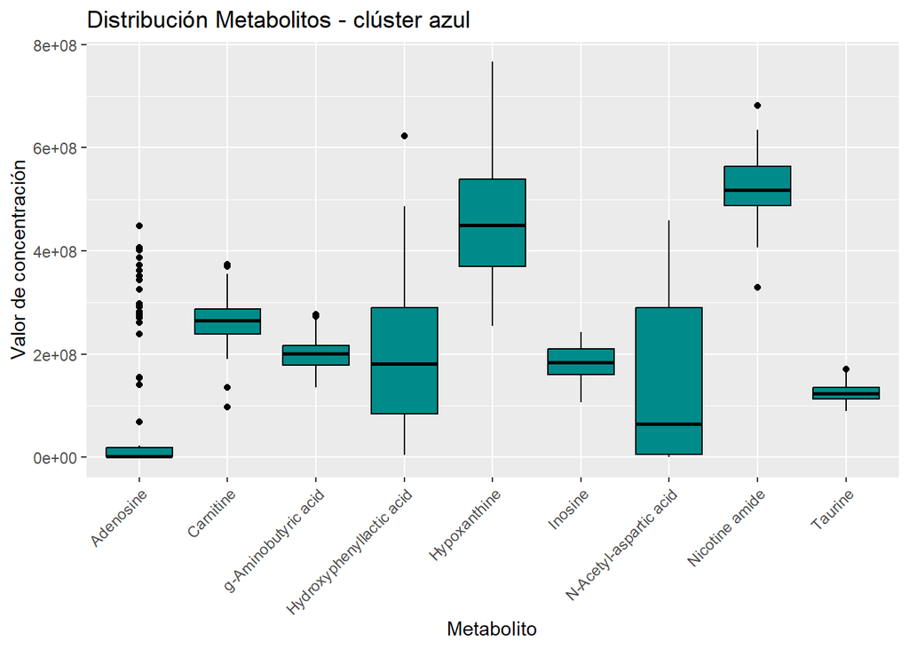

```r
# Filtrar metabolitos clúster azul
metabolitos_azul <- c("Adenosine", "Carnitine", "g-Aminobutyric acid",
                      "Hydroxyphenyllactic acid", "Hypoxanthine", "Inosine",
                      "N-Acetyl-aspartic acid", "Nicotine amide", "Taurine")
df_clusterazul <- subset(df_metab_largo, Metabolito %in% metabolitos_azul)


ggplot(df_clusterazul, aes(x = Metabolito, y = Valor)) +
  geom_boxplot(fill = "cyan4", color = "black") +
  labs(title = "Distribución Metabolitos - clúster azul",
    x = "Metabolito",
    y = "Valor de concentración") +
  theme(axis.text.x = element_text(angle = 45, hjust = 1))
```

El gráfico muestra que *Hypoxanthine* y *N-Acetyl-aspartic acid* tienen alta variabilidad en sus concentraciones, mientras que *Adenosine* presenta valores bajos con bastantes outliers. Por otro lado, *g-Aminobutyric acid*, *Inosine* y *Taurine* son más estables entre muestras.

## 4.4 Análisis PCA

El objetivo del análisis de componentes principales (PCA) es reducir la dimensionalidad de los datos. Los primeros componentes principales capturan la mayor parte de la variabilidad y se facilita la visualización de patrones en las muestras y metabolitos.

### 4.4.1 Variablidad explicada por componente

Se calcula la variabilidad explicada por cada componente para determinar cuántas componentes son necesarias para capturar una cantidad aceptable de la variabilidad total de los datos.

Como muestra el gráfico de barras, las dos primeras componentes principales (PC1 y PC2) explican una gran parte de la variabilidad: PC1 explica aproximadamente el 34% y PC2 el 20%.

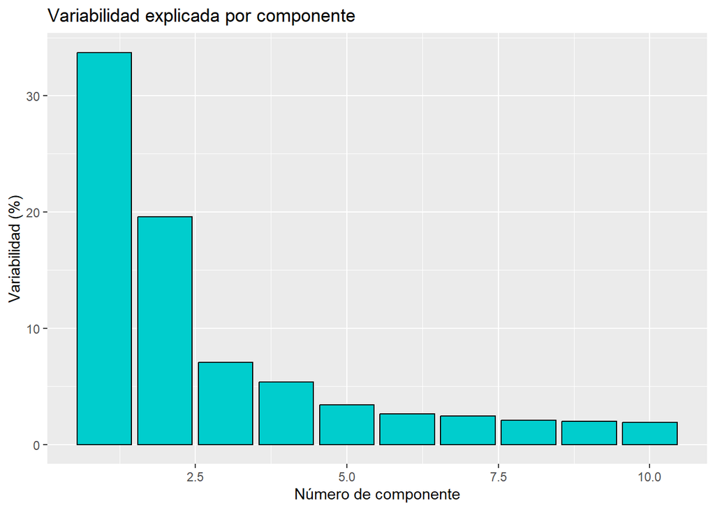

```r
tune.pca_metabolitos <- tune.pca(metabolitos_df, ncomp = 10, scale = TRUE)

# Porcentaje de la variabilidad
var_explicada <- tune.pca_metabolitos$prop_expl_var$X * 100

df_variabilidad <- data.frame(
  Componentes = 1:length(var_explicada),
  Variabilidad = var_explicada
)

ggplot(df_variabilidad, aes(x = Componentes, y = Variabilidad)) +
  geom_bar(stat = "identity", fill = "cyan3", color="black") +
  labs(
    title = "Variabilidad explicada por componente",
    x = "Número de componente",
    y = "Variabilidad (%)")
```

A continuación se muestras los valores de la variabilidad acumulada hasta el decimo componente principal.

```r
PCA10_metab <- pca(metabolitos_df, ncomp = 10, center = TRUE, scale = TRUE)
PCA10_metab$cum.var
```

```
##       PC1       PC2       PC3       PC4       PC5       PC6       PC7       PC8
## 0.3371549 0.5328263 0.6034837 0.6570484 0.6909815 0.7172116 0.7416258 0.7626408
##       PC9      PC10
## 0.7824020 0.8013619
```

Las 5 primeras componentes casi explica el 70% de la variabilidad de los datos, lo cual es suficiente para obtener una representación de las principales fuentes de variación en los datos.

El siguiente gráfico muestra la distribución de las muestras en el plano de las dos primeras componentes principales (PC1 y PC2). Cada punto representa una muestra etiquetada con su identificador, que incluye el tipo de tratamiento y el Zeitgeber time (ZT).

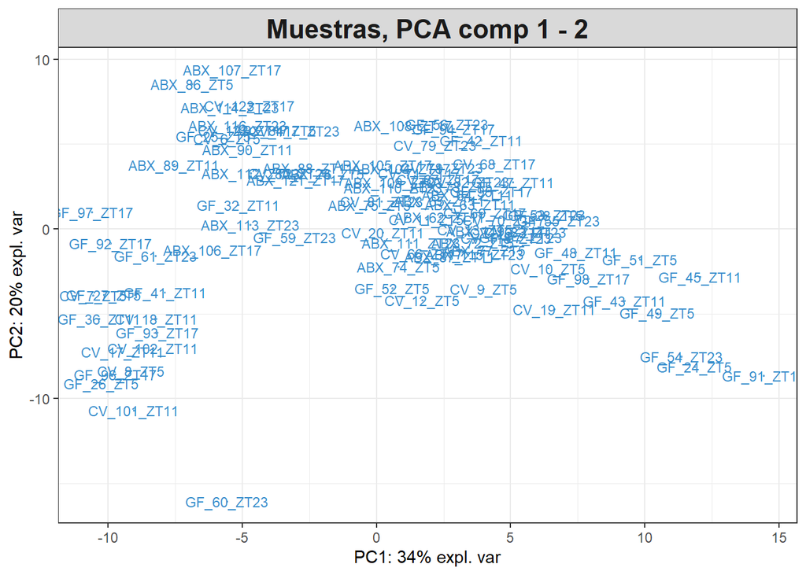

```r
PCA5_metab <- pca(metabolitos_df, ncomp = 5, center = TRUE, scale = TRUE)
plotIndiv(PCA5_metab, title = 'Muestras, PCA comp 1 - 2')
```

No se observa una clara separación de las muestras por tratamiento (ABX, GF, CV) ni por Zeitgeber time, lo que indica que la variabilidad explicada por las primeras dos componentes no está directamente asociada con estos factores de forma evidente.

### 4.4.2 Proyección de metabolitos en el espacio de PC

El siguiente gráfico muestra cómo se proyectan los metabolitos en el espacio definido por las dos primeras componentes principales. Cada punto representa un metabolito, y su posición muestra cómo contribuye a las componentes principales. Los metabolitos que se encuentran más cerca de los extremos (bordes) de los ejes PC1 y PC2 tienen una mayor influencia en la variabilidad explicada por esas componentes.

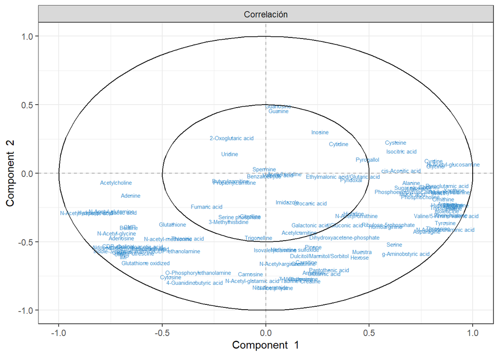

```r
plotVar(PCA5_metab, cex=2, title = "Correlación" )
```

# 5 Discusión, limitaciones y conclusiones del estudio

Los resultados del clustering hacen pensar que algunos metabolitos presentan patrones similares, y es posible que las respuestas estén relacionadas con el tratamiento o al ciclo circadiano. Si los metabolitos en un clúster están asociados a funciones o rutas metabólicas específicas, esto podría señalar áreas del metabolismo que responden conjuntamente a los factores experimentales. En el contexto de este estudio, estos patrones podrían reflejar cómo la microbiota y el ritmo circadiano influyen en algunos procesos metabólicos.

Los resultados del análisis PCA muestra agrupaciones de metabolitos con patrones de variación similares, sugiriendo posibles relaciones funcionales o rutas metabólicas comunes [3]. Metabolitos como *2-Oxoglutaric acid* y *Uridine* se proyectan en direcciones cercanas, lo que indica que podrían estar correlacionados, aunque no con un valor superior a 0,95, o responder a factores experimentales. Sin embargo, el PCA solo explica una parte de la variabilidad, por lo que no captura todas las posibles interacciones metabólicas influenciadas por el tratamiento y el tiempo circadiano.

Algunas limitaciones adicionales proceden de que este estudio es parte de un proyecto mayor sobre cómo la microbiota intestinal afecta los ritmos circadianos de metabolitos en el cerebro y su relación con el sistema de respuesta al estrés (eje HPA). Sin embargo, faltan datos sobre la regulación de glucocorticoides y la actividad rítmica del HPA, lo que limita el análisis directo de estas interacciones en este análisis [1].

# 6 Referencias

[1] This data is available at the NIH Common Fund’s National Metabolomics Data Repository (NMDR) website, the Metabolomics Workbench, https://www.metabolomicsworkbench.org, where it has been assigned Project ID PR002130. The data can be accessed directly via it’s Project DOI: 10.21228/M89525 This work is supported by NIH grant, U2C- DK119886.

[2] Dyar KA, Eckel-Mahan KL. Circadian Metabolomics in Time and Space. Front Neurosci. 2017 Jul 11;11:369. doi: 10.3389/fnins.2017.00369. PMID: 28744188; PMCID: PMC5504240.

[3] Nyamundanda, G., Brennan, L. & Gormley, I.C. Probabilistic principal component analysis for metabolomic data. BMC Bioinformatics 11, 571 (2010). https://doi.org/10.1186/1471-2105-11-571

## 6.1 GitHub

El código y los datos de este análisis están disponibles en el [repositorio de GitHub](https://github.com/mercemerayo/Merayo-Pastor-Merce-PEC1).